# Introduction to Factorial Designs Problem Set - 2^K Designs

# 1 Half Fractional Question

*Note, this problem is adapted from Montgomery 2017, Question 8.10*

You have an experiment with five factors, A, B, C, D, and E. You ran three replicates of each of 16 treatment combinations. Your results are contained in montgomery_8_10.csv .

## 1.1 Read and Format the Data as Required

```r
myData <- read.csv('montgomery_8_10.csv')
myData
```

```
##     A  B  C  D  E Rep.1 Rep.2 Rep.3
## 1  -1 -1 -1 -1 -1  7.78  7.78  7.81
## 2   1 -1 -1  1 -1  8.15  8.18  7.88
## 3  -1  1 -1  1 -1  7.50  7.56  7.50
## 4   1  1 -1 -1 -1  7.59  7.56  7.75
## 5  -1 -1  1  1 -1  7.54  8.00  7.88
## 6   1 -1  1 -1 -1  7.69  8.09  8.06
## 7  -1  1  1 -1 -1  7.56  7.52  7.44
## 8   1  1  1  1 -1  7.56  7.81  7.69
## 9  -1 -1 -1 -1  1  7.50  7.25  7.12
## 10  1 -1 -1  1  1  7.88  7.88  7.44
## 11 -1  1 -1  1  1  7.50  7.56  7.50
## 12  1  1 -1 -1  1  7.63  7.75  7.56
## 13 -1 -1  1  1  1  7.32  7.44  7.44
## 14  1 -1  1 -1  1  7.56  7.69  7.62
## 15 -1  1  1 -1  1  7.18  7.18  7.25
## 16  1  1  1  1  1  7.81  7.50  7.59
```

## 1.2 Understand the Design

1. Write out the alias structure of this design.

```r
# This is clearly a half fractional factorial design
# It was a little bit of trial and error to ID the generator
myData %>% select(-c(Rep.1, Rep.2, Rep.3)) %>%
  mutate(ABCD = A*B*C*D)
```

```
##     A  B  C  D  E ABCD
## 1  -1 -1 -1 -1 -1    1
## 2   1 -1 -1  1 -1    1
## 3  -1  1 -1  1 -1    1
## 4   1  1 -1 -1 -1    1
## 5  -1 -1  1  1 -1    1
## 6   1 -1  1 -1 -1    1
## 7  -1  1  1 -1 -1    1
## 8   1  1  1  1 -1    1
## 9  -1 -1 -1 -1  1    1
## 10  1 -1 -1  1  1    1
## 11 -1  1 -1  1  1    1
## 12  1  1 -1 -1  1    1
## 13 -1 -1  1  1  1    1
## 14  1 -1  1 -1  1    1
## 15 -1  1  1 -1  1    1
## 16  1  1  1  1  1    1
```

```r
# We see we took the principal fraction of I = ABCD
```

```
We can then write out the alias structure

## First find main effects (5 main effects)
A = A*ABCD = BCD
B = B*ABCD = ACD
C = C*ABCD = ABD
D = D*ABCD = ABC
E = E*ABCD = ABCDE

## Next ID 2nd order effects (10 2nd order)
AB = AB*ABCD = CD
AC = AC*ABCD = BD
AD = AD*ABCD = BC
AE = AE*ABCD = BCDE
BE = BE*ABCD = ACDE
CE = CE*ABCD = ABDE
DE = DE*ABCD = ABCE

## Next ID 3rd order effects (10 3rd order) note 4 are aliased with first order
ABE = ABE*ABCD = CED
ACE = ACE*ABCD = BDE
ADE = ADE*ABCD = BCE

## Next ID 4th order effects (5 4th order) and 5th order
I = ABCD
The other 5 are aliased with 2nd order effects
ABCDE is aliased with E
```

2. What is the design generator? What is the defining relation? Is this a principal or alternate fraction?

```
The design generator is ABCD.
The defining relation is I = ABCD.
We are taking the principal fraction.
```

## 1.3 Analyze the Results

1. Visualize the main effects and interpret your results

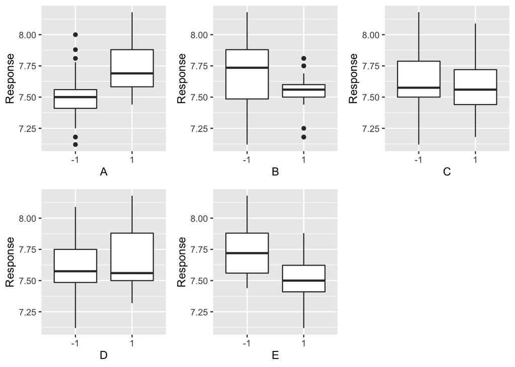

```r
myTempData <- myData %>%
  pivot_longer(cols = c(Rep.1, Rep.2, Rep.3), names_to = 'Replicate', values_to = 'Response') %>%
  mutate(A = as.factor(A), B = as.factor(B), C = as.factor(C), D = as.factor(D), E = as.factor(E))

ggpubr::ggarrange(
  ggplot(myTempData) + geom_boxplot(aes(x = A, y = Response)),
  ggplot(myTempData) + geom_boxplot(aes(x = B, y = Response)),
  ggplot(myTempData) + geom_boxplot(aes(x = C, y = Response)),
  ggplot(myTempData) + geom_boxplot(aes(x = D, y = Response)),
  ggplot(myTempData) + geom_boxplot(aes(x = E, y = Response))
)
```

```r
# A and E are likely significant.  Possibly B.  We some potential variation in variance with B at 1 and A at -1
```

2. Visualize 2nd order interaction effects.

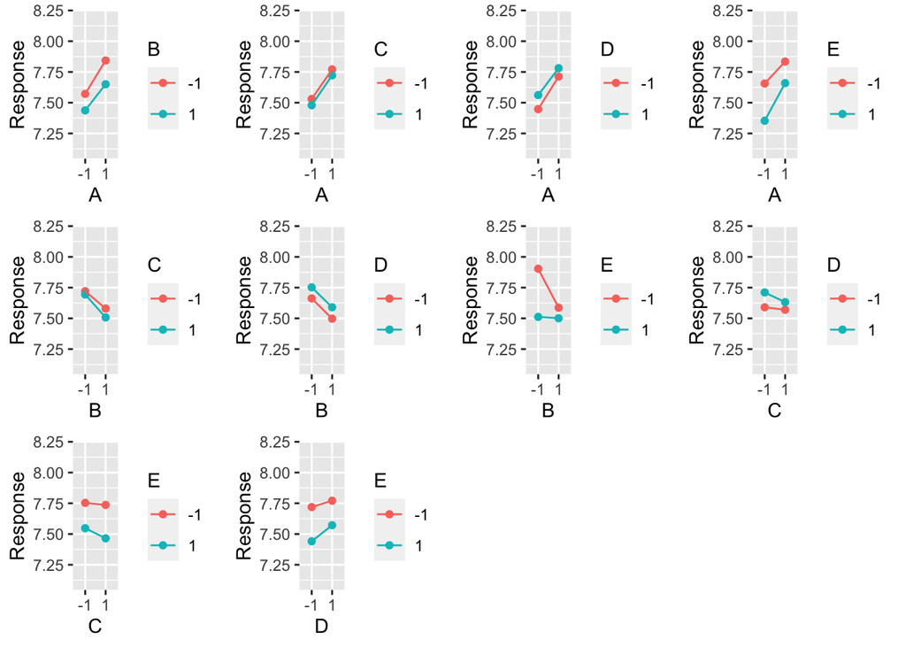

```r
ggpubr::ggarrange(
  #AB
  ggplot(myTempData, aes(x = A, y = Response, group = B, color = B)) +
    stat_summary(fun = 'mean', geom = 'point') + stat_summary(fun = 'mean', geom = 'line') +
    ylim(c(7.1, 8.2)),
  #AC
  ggplot(myTempData, aes(x = A, y = Response, group = C, color = C)) +
    stat_summary(fun = 'mean', geom = 'point') + stat_summary(fun = 'mean', geom = 'line') +
    ylim(c(7.1, 8.2)),
  #AD
  ggplot(myTempData, aes(x = A, y = Response, group = D, color = D)) +
    stat_summary(fun = 'mean', geom = 'point') + stat_summary(fun = 'mean', geom = 'line') +
    ylim(c(7.1, 8.2)),
    #AE
  ggplot(myTempData, aes(x = A, y = Response, group = E, color = E)) +
    stat_summary(fun = 'mean', geom = 'point') + stat_summary(fun = 'mean', geom = 'line') +
    ylim(c(7.1, 8.2)),
    #BC
  ggplot(myTempData, aes(x = B, y = Response, group = C, color = C)) +
    stat_summary(fun = 'mean', geom = 'point') + stat_summary(fun = 'mean', geom = 'line') +
    ylim(c(7.1, 8.2)),
    #BD
  ggplot(myTempData, aes(x = B, y = Response, group = D, color = D)) +
    stat_summary(fun = 'mean', geom = 'point') + stat_summary(fun = 'mean', geom = 'line') +
    ylim(c(7.1, 8.2)),
    #BE
  ggplot(myTempData, aes(x = B, y = Response, group = E, color = E)) +
    stat_summary(fun = 'mean', geom = 'point') + stat_summary(fun = 'mean', geom = 'line') +
    ylim(c(7.1, 8.2)),
    #CD
  ggplot(myTempData, aes(x = C, y = Response, group = D, color = D)) +
    stat_summary(fun = 'mean', geom = 'point') + stat_summary(fun = 'mean', geom = 'line') +
    ylim(c(7.1, 8.2)),
    #CE
  ggplot(myTempData, aes(x = C, y = Response, group = E, color = E)) +
    stat_summary(fun = 'mean', geom = 'point') + stat_summary(fun = 'mean', geom = 'line') +
    ylim(c(7.1, 8.2)),
    #DE
  ggplot(myTempData, aes(x = D, y = Response, group = E, color = E)) +
    stat_summary(fun = 'mean', geom = 'point') + stat_summary(fun = 'mean', geom = 'line') +
    ylim(c(7.1, 8.2))
)
```

```r
# It appears that B and E have an interaction, and possibly A and E.
# Note - when I first ploted these, each plot produced its own y scale, so it
# made it hard to really compare.  Be aware of scales when comparing plots!
# I went back and added the y scale to be from 7.1 to 8.2 which is about the
# range of the response data
```

3. Calculate the effect for each main and second order effect:

```r
### First find main effects (5 main effects)
#[A] = [BCD] -> A + BCD
E.A <- (1/(3*(2^(5-1-1))))*sum(myData$A * (myData$Rep.1 + myData$Rep.2 + myData$Rep.3))
#[B] = [ACD] -> B + ACD
E.B <- (1/(3*(2^(5-1-1))))*sum(myData$B * (myData$Rep.1 + myData$Rep.2 + myData$Rep.3))
#[C] = [ABD] -> C + ABD
E.C <- (1/(3*(2^(5-1-1))))*sum(myData$C * (myData$Rep.1 + myData$Rep.2 + myData$Rep.3))
#[D] = [ABC] -> D + ABC
E.D <- (1/(3*(2^(5-1-1))))*sum(myData$D * (myData$Rep.1 + myData$Rep.2 + myData$Rep.3))
#[E] = [ABCDE] -> E + ABCDE
E.E <- (1/(3*(2^(5-1-1))))*sum(myData$E * (myData$Rep.1 + myData$Rep.2 + myData$Rep.3))
#
### Next ID 2nd order effects (10 2nd order)
#[AB] = [CD]
E.AB <- (1/(3*(2^(5-1-1))))*sum(myData$A *myData$B * (myData$Rep.1 + myData$Rep.2 + myData$Rep.3))
#AC = AC*ABCD = BD
E.AC <- (1/(3*(2^(5-1-1))))*sum(myData$A *myData$C * (myData$Rep.1 + myData$Rep.2 + myData$Rep.3))
#AD = AD*ABCD = BC
E.AD <- (1/(3*(2^(5-1-1))))*sum(myData$A *myData$D * (myData$Rep.1 + myData$Rep.2 + myData$Rep.3))
#AE = AE*ABCD = BCDE
E.AE <- (1/(3*(2^(5-1-1))))*sum(myData$A *myData$E * (myData$Rep.1 + myData$Rep.2 + myData$Rep.3))
#BE = BE*ABCD = ACDE
E.BE <- (1/(3*(2^(5-1-1))))*sum(myData$B *myData$E * (myData$Rep.1 + myData$Rep.2 + myData$Rep.3))
#CE = CE*ABCD = ABDE
E.CE <- (1/(3*(2^(5-1-1))))*sum(myData$C *myData$E * (myData$Rep.1 + myData$Rep.2 + myData$Rep.3))
#DE = DE*ABCD = ABCE
E.DE <- (1/(3*(2^(5-1-1))))*sum(myData$D *myData$E * (myData$Rep.1 + myData$Rep.2 + myData$Rep.3))
#
### Next ID 3rd order effects (10 3rd order) note 4 are aliased with first order
#ABE = ABE*ABCD = CED
#ACE = ACE*ABCD = BDE
#ADE = ADE*ABCD = BCE

myResults <- data.frame(
  Effect = c(E.A, E.B, E.C, E.D, E.E, E.AB, E.AC, E.AD, E.AE, E.BE, E.CE, E.DE),
  Factor.Name = c("A", 'B', 'C', 'D', 'E', 'AB', 'AC', 'AD', 'AE', 'BE', 'CE', 'DE')
)
myResults
```

```
##         Effect Factor.Name
## 1   0.24208333           A
## 2  -0.16375000           B
## 3  -0.04958333           C
## 4   0.09125000           D
## 5  -0.23875000           E
## 6  -0.02958333          AB
## 7   0.00125000          AC
## 8  -0.02291667          AD
## 9   0.06375000          AE
## 10  0.15291667          BE
## 11 -0.03291667          CE
## 12  0.03958333          DE
```

4. Plot the effects on a normal probability plot.

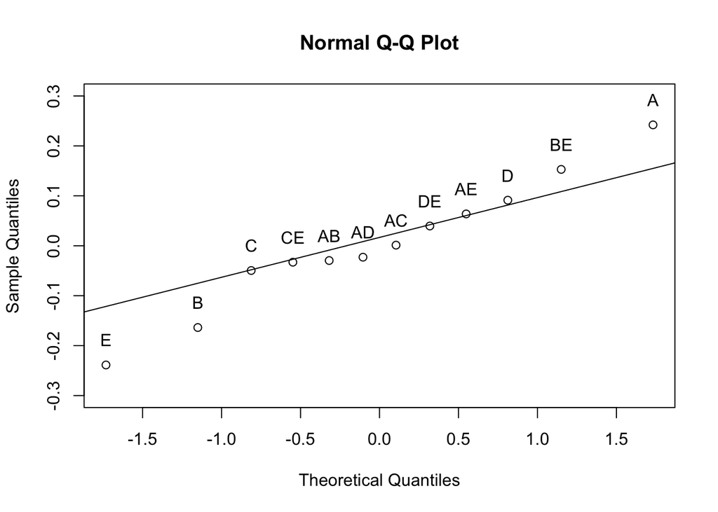

```r
temp.coord <- qqnorm(myResults$Effect, ylim = c(-.3, .3))
qqline(myResults$Effect)
text(x = temp.coord$x, y = temp.coord$y + .05, labels = myResults$Factor.Name)
```

5. Based on your visualization and effects analysis, what do you conclude?

```
It appears that A, B, E, and B:E are all significant in this experiment.
Further experimentation, analysis or modeling, perhaps only using those three factors
would be useful and informative.
```

# 2 Conceptual Question

If you are in a scenario in which you have many factors, each at two levels, but only a fixed number of possible runs, does it make more sense to:

- Do a full factorial experiment with only a single replicate of each treatment combination?
- Do a fractional factorial experiment with multiple replicates of the tested treatment combinations?

```
The answer to this question is that it depends.  It depends on a number of things.  A few considerations:

1. How well do you trust the outcome of your tests?  That is, if you have reason to believe that any given
test has an output with a small variance, you increase the likelihood of producing a reasonable answer
with a single replicate, and thus gain some more information doing the full factorial experiment.  Of course,
the converse is true if you are unsure of your test.

2. How likely do think higher order interactions are to be significant?  If you think anything higher
than 2nd order is likely to be insignificant, you can safely gain accuracy on your tests (via replication)
at the expense of aliasing.

3. How likely do you think all of your factors are significant.  If you think that some number of factors
are likely to be insignificant, you will in effect gain replicates by identifying and discarding them
in your analysis.  This may suggest that you are better off with an unreplicated full factorial design.
```